# Exploratory Analysis for Socio-economic Data

Alexandre Arcos Pujades

2024-05-20

# Introduction

The purpose of this guide is to offer local economic development practitioners a step by step methodology to analyse data of a social and economic nature. It employs a synthetic dataset that mimics a real household survey used in one of the projects implemented by the United Nation’s Human Settlements Programme (UN-Habitat).

The second part of the guide focuses on conducting a so-called Exploratory Data Analysis (EDA) by analyzing and visualizing the patterns, distributions, and relationships within the dataset.

It covers techniques for both numerical and categorical variables. For numerical data, the guide demonstrates how to calculate descriptive statistics such as measures of central tendency, range, dispersion, and quartiles. It then shows how to visualize these variables using boxplots, histograms, and density plots to understand their distributions.

For categorical data, the guide explains how to create frequency and relative frequency tables to see the count and proportion of observations in each category. It also demonstrates how to count the number of “Select” responses for specific groups of variables. Bar charts, stacked bar charts, and pie charts are used to visualize the categorical variables and compare counts or percentages across categories.

Finally, the guide covers correlation analysis to measure the relationships between variables. It shows how to calculate and visualize Pearson correlation for continuous variables, Spearman correlation between a continuous and ordinal variable, and point-biserial correlation between continuous and binary variables. The last section introduces the concept of the Simpson Paradox, that is useful to understand the next part of the guide.

There are numerous free, online resources that describe in a detailed manner how to properly explore data:

- [Exploratory Data Analysis I](https://users.metu.edu.tr/ozancan/eda1.html)
- [Exploratory Data Analysis: A tutorial about data analysis using R (Website Version)](https://www.ucd.ie/ecomodel/Resources/Sheet3_visualisation_WebVersion.html#saving-a-plot-as-an-image-file)
- [Montana State Introductory Statistics with R: Fall 2022](https://mtstateintrostats.github.io/IntroStatTextbook/eda.html#categorical-data)
- [UG Quantitative Methods in the Social Sciences lab workbook](https://bookdown.org/jovet255/lab-workbook/exploratory-data-analysis.html)
- [Discdown - Chapter 4 Basic exploratory data analysis](https://discdown.org/dataanalytics/basic-exploratory-data-analysis.html)
- [Descriptive statistics in R](https://statsandr.com/blog/descriptive-statistics-in-r/#minimum-and-maximum)

## Case Description

The fictional country of Lvneel has hired our team to analyse a survey prepared by a local NGO by interviewing a large number of households. The client wants to understand how socio-demographic variables (age, sex, marital status, ethnic group, district…) impact different quality of life indicators.

A summary of the data contained in each variable of the dataset can be found in the [Data Dictionary](https://docs.google.com/spreadsheets/d/1BGSSNHbM8WzLIjpf4B2ypOuXvmSyZsJC/edit?usp=sharing&ouid=105664068897260112805&rtpof=true&sd=true).

# Getting to Know our Data

## Loading Necessary Libraries and Dataset

This step involves loading the dataset we’ll be working with and the libraries that will allow us to manipulate and visualize the data. `tidyverse` includes several packages like `ggplot2` for plotting, and `dplyr` for data manipulation.

```r
# We load necessary libraries for data manipulation and visualization
library(tidyverse)
library(readxl)
library(knitr)

# We load our dataset
hh_survey<-read_xlsx("complete_survey.xlsx")
```

## Geographic and Demographic Overview of the Survey Sample

Before diving into deeper analyses, it is essential to understand how our survey sample is distributed across different districts and nationalities. This section provides an overview of the geographic distribution of respondents, highlighting the number of observations per district and the ethnic composition of each area.

```r
#️ Count the number of observations per district
district_counts <- hh_survey %>%
  filter(!is.na(District)) %>%
  group_by(District) %>%
  summarise(Count = n(), .groups = "drop") %>%
  mutate(Percentage = (Count / sum(Count)) * 100)

# Display district counts in a table
kable(district_counts, caption = "Number of Observations per District")
```

Number of Observations per District

| District | Count | Percentage |
| --- | --- | --- |
| Flower Capital | 3646 | 19.70811 |
| Hakumai | 2765 | 14.94595 |
| Kibi | 3324 | 17.96757 |
| Kuri | 3267 | 17.65946 |
| Ringo | 2490 | 13.45946 |
| Udon | 3008 | 16.25946 |

```r
# Nationalities per district
# Count the observations by nationality_group and district
nationality_district_counts <- hh_survey %>%
  filter(!is.na(Informant_nationality), !is.na(District)) %>%
  count(Informant_nationality, District) %>%
  group_by(District) %>%
  mutate(In_Group_Percentage = (n / sum(n)) * 100) %>%  # % within each district
  ungroup() %>%
  mutate(Overall_Percentage = (n / sum(n)) * 100)  # % over total sample

# Create the table using kable
nationality_table <- nationality_district_counts %>%
  select(District, Informant_nationality, n, Overall_Percentage, In_Group_Percentage) %>%
  arrange(District, desc(n)) %>%
  kable(caption = "Nationality Distribution by District")

# Print the table
print(nationality_table)
```

```
##
##
## Table: Nationality Distribution by District
##
## |District       |Informant_nationality |    n| Overall_Percentage| In_Group_Percentage|
## |:--------------|:---------------------|----:|------------------:|-------------------:|
## |Flower Capital |Shandian              |  766|          4.1405405|           21.009325|
## |Flower Capital |Fish-Man              |  527|          2.8486486|           14.454196|
## |Flower Capital |Merfolk               |  523|          2.8270270|           14.344487|
## |Flower Capital |Skypiean              |  369|          1.9945946|           10.120680|
## |Flower Capital |Three-Eye             |  363|          1.9621622|            9.956116|
## |Flower Capital |Longleg               |  327|          1.7675676|            8.968733|
## |Flower Capital |Lunarian              |  289|          1.5621622|            7.926495|
## |Flower Capital |Birkan                |  262|          1.4162162|            7.185957|
## |Flower Capital |Longarm               |  220|          1.1891892|            6.034010|
## |Hakumai        |Longarm               |  546|          2.9513514|           19.746835|
## |Hakumai        |Three-Eye             |  427|          2.3081081|           15.443038|
## |Hakumai        |Longleg               |  376|          2.0324324|           13.598553|
## |Hakumai        |Lunarian              |  311|          1.6810811|           11.247740|
## |Hakumai        |Merfolk               |  299|          1.6162162|           10.813743|
## |Hakumai        |Skypiean              |  282|          1.5243243|           10.198915|
## |Hakumai        |Fish-Man              |  260|          1.4054054|            9.403255|
## |Hakumai        |Shandian              |  136|          0.7351351|            4.918626|
## |Hakumai        |Birkan                |  128|          0.6918919|            4.629295|
## |Kibi           |Three-Eye             | 1394|          7.5351351|           41.937425|
## |Kibi           |Fish-Man              |  366|          1.9783784|           11.010830|
## |Kibi           |Merfolk               |  322|          1.7405405|            9.687124|
## |Kibi           |Shandian              |  278|          1.5027027|            8.363418|
## |Kibi           |Birkan                |  268|          1.4486486|            8.062575|
## |Kibi           |Longleg               |  208|          1.1243243|            6.257521|
## |Kibi           |Skypiean              |  205|          1.1081081|            6.167268|
## |Kibi           |Lunarian              |  160|          0.8648649|            4.813478|
## |Kibi           |Longarm               |  123|          0.6648649|            3.700361|
## |Kuri           |Fish-Man              |  680|          3.6756757|           20.814203|
## |Kuri           |Shandian              |  588|          3.1783784|           17.998164|
## |Kuri           |Skypiean              |  411|          2.2216216|           12.580349|
## |Kuri           |Three-Eye             |  351|          1.8972973|           10.743802|
## |Kuri           |Merfolk               |  302|          1.6324324|            9.243955|
## |Kuri           |Longarm               |  268|          1.4486486|            8.203245|
## |Kuri           |Birkan                |  257|          1.3891892|            7.866544|
## |Kuri           |Lunarian              |  224|          1.2108108|            6.856443|
## |Kuri           |Longleg               |  186|          1.0054054|            5.693297|
## |Ringo          |Birkan                |  431|          2.3297297|           17.309237|
## |Ringo          |Shandian              |  412|          2.2270270|           16.546185|
## |Ringo          |Skypiean              |  400|          2.1621622|           16.064257|
## |Ringo          |Fish-Man              |  327|          1.7675676|           13.132530|
## |Ringo          |Merfolk               |  324|          1.7513514|           13.012048|
## |Ringo          |Three-Eye             |  190|          1.0270270|            7.630522|
## |Ringo          |Longleg               |  163|          0.8810811|            6.546185|
## |Ringo          |Lunarian              |  151|          0.8162162|            6.064257|
## |Ringo          |Longarm               |   92|          0.4972973|            3.694779|
## |Udon           |Three-Eye             | 1140|          6.1621622|           37.898936|
## |Udon           |Merfolk               |  430|          2.3243243|           14.295213|
## |Udon           |Shandian              |  392|          2.1189189|           13.031915|
## |Udon           |Lunarian              |  236|          1.2756757|            7.845745|
## |Udon           |Longarm               |  205|          1.1081081|            6.815160|
## |Udon           |Skypiean              |  191|          1.0324324|            6.349734|
## |Udon           |Longleg               |  180|          0.9729730|            5.984043|
## |Udon           |Birkan                |  139|          0.7513514|            4.621011|
## |Udon           |Fish-Man              |   95|          0.5135135|            3.158245|
```

## Data Types

This is a preparatory step in our data analysis process, aimed at categorizing the variables in the dataset into numeric and character types.

Knowing the data type of each variable is foundational for conducting the EDA. Different data types require different types of analysis; for instance, numeric variables can be summarized with means or medians, while categorical (character) variables might be analyzed through frequencies or mode.

```r
# Revised lists for numeric and categorical variables
numeric_vars <- names(hh_survey %>% select_if(is.numeric))
character_vars <- names(hh_survey %>% select_if(is.character))

# Print character variables
print(numeric_vars)
```

```
##  [1] "Latitude"              "Longitude"             "AnnualRent"
##  [4] "PropertyLike_binary"   "HouseholdLivingYears"  "Neighlike_Binary"
##  [7] "NeighSafety"           "Security_binary"       "hh_income"
## [10] "InformantAge"          "Informant_dailyhours"  "Informant_income"
## [13] "Informant_commutetime" "worktrip_cost"
```

```r
print(character_vars)
```

```
##  [1] "ï..RespondentUniqueID"         "District"
##  [3] "BuildingType"                  "Utility_electricity_available"
##  [5] "Utility_water_available"       "Utility_sanitation_available"
##  [7] "Internet_hotspot"              "Internet_WiFi"
##  [9] "Internet_none"                 "Neighlike_accestoserv"
## [11] "Neighlike_housingaffor"        "Neighlike_nearcommun"
## [13] "Neighlike_nearwork"            "Neighlike_localIdentity"
## [15] "Neighlike_parksrecravaila"     "Neighlike_issues_binary"
## [17] "Issues_welcoming"              "Issues_streets"
## [19] "Issues_noise"                  "Issues_buildings"
## [21] "Issues_pedestrians"            "Issues_parks"
## [23] "Issues_crime"                  "Issues_trafficparking"
## [25] "Issues_cleanliness"            "Issues_shopping"
## [27] "Issues_school"                 "Issues_pollution"
## [29] "Security_homerobbery"          "Security_carrobbery"
## [31] "Security_personalrobbery"      "Security_womenharassment"
## [33] "Security_childrenharassment"   "Security_physicalattack"
## [35] "Security_verbalattack"         "Security_drugsalcohol"
## [37] "InformantGender"               "Informant_marital"
## [39] "Informant_edulevel"            "Informant_econactivity"
## [41] "Informant_workcommute"         "PlanToUseMetro"
## [43] "Informant_nationality"         "nationality_group"
## [45] "marital_status_group"          "income_group"
## [47] "age_group"
```

# Working with Numerical Data

## Descriptive Statistics

Descriptive statistics provide a concise summary of data sets through measures that describe the center, spread, and shape of the data distribution. They include calculations such as the mean, median, mode, range, variance, standard deviation, and quartiles.

They facilitate the detection of patterns, outliers, and anomalies, which can guide more detailed analysis and help in decision-making processes.

### Measures of Central Tendency

Measures of central tendency describe the central or typical value within a dataset. These include the mean, which represents the arithmetic average; the median, which is the middle value when data is ordered; and the mode, which is the most frequently occurring value. These measures provide insight into the general location of data points within a distribution.

```r
# First we specify the numerical variables
numeric_vars <- c("AnnualRent", "HouseholdLivingYears", "NeighSafety",
                  "hh_income", "InformantAge", "Informant_dailyhours",
                  "Informant_income", "Informant_commutetime", "worktrip_cost")

# We calculate the mean and median for each specified numeric variable
mean_median <- sapply(hh_survey[numeric_vars], function(x) {
    c(mean = mean(x, na.rm = TRUE), median = median(x, na.rm = TRUE))
})

# We print the calculated statistics
print(mean_median)
```

```
##        AnnualRent HouseholdLivingYears NeighSafety hh_income InformantAge
## mean     4245.638             7.053378    3.113243  1233.919     34.55081
## median   3600.000             7.000000    3.000000   900.000     33.00000
##        Informant_dailyhours Informant_income Informant_commutetime
## mean               8.049838         883.5946              15.43581
## median             8.000000         600.0000              15.00000
##        worktrip_cost
## mean        4.826182
## median      4.000000
```

### Range and Upper and Lower Limits

The range is the simplest measure of spread, calculated as the difference between the maximum and minimum values in a dataset. The upper and lower limits refer to the boundaries that help detect outliers, often based on statistical rules such as quartiles or standard deviations from the mean.

```r
# We calculate min, max, and range for each specified numeric variable
min_max_range <- sapply(hh_survey[numeric_vars], function(x) {
    c(
        min = min(x, na.rm = TRUE),
        max = max(x, na.rm = TRUE),
        range = max(x, na.rm = TRUE) - min(x, na.rm = TRUE)
    )
})

# We print the calculated statistics
print(min_max_range)
```

```
##       AnnualRent HouseholdLivingYears NeighSafety hh_income InformantAge
## min          900                    1           1       300           18
## max        20500                   12           5      6000           75
## range      19600                   11           4      5700           57
##       Informant_dailyhours Informant_income Informant_commutetime worktrip_cost
## min                      4              100                     5             2
## max                     12             5500                    30             9
## range                    8             5400                    25             7
```

### Measures of Dispersion

Dispersion measures indicate how spread out the values in a dataset are. The variance quantifies the average squared deviation from the mean, while the standard deviation represents the square root of variance, offering a more interpretable measure of variability. These metrics are essential for understanding the consistency or variability of the data.

```r
# We calculate variance and standard deviation for each specified numeric variable
variance_sd <- sapply(hh_survey[numeric_vars], function(x) {
    c(
        Variance = var(x, na.rm = TRUE),  # Variance of the variable
        Std_Dev = sd(x, na.rm = TRUE)     # Standard deviation of the variable
    )
})

# We print the calculated statistics
print(variance_sd)
```

```
##           AnnualRent HouseholdLivingYears NeighSafety   hh_income InformantAge
## Variance 5735153.142             4.217439   0.7137551 802889.1226    144.42852
## Std_Dev     2394.818             2.053641   0.8448403    896.0408     12.01784
##          Informant_dailyhours Informant_income Informant_commutetime
## Variance             4.866320      466225.7938             26.671304
## Std_Dev              2.205974         682.8073              5.164427
##          worktrip_cost
## Variance      5.595226
## Std_Dev       2.365423
```

### Quartiles

Quartiles divide data into four equal parts, providing a detailed view of the distribution. The first quartile (Q1) marks the 25th percentile, the third quartile (Q3) the 75th percentile, and the interquartile range (IQR) (Q3 - Q1) measures the middle 50% spread of the data. Quartiles help in identifying skewness and potential outliers.

```r
# We calculate the first quartile, third quartile, and interquartile range for each specified numeric variable
quartiles_and_iqr <- sapply(hh_survey[numeric_vars], function(x) {
    c(
        Q1 = quantile(x, 0.25, na.rm = TRUE),      # First quartile (25th percentile)
        Q3 = quantile(x, 0.75, na.rm = TRUE),      # Third quartile (75th percentile)
        IQR = IQR(x, na.rm = TRUE)                 # Interquartile range
    )
})

# We print the calculated statistics
print(quartiles_and_iqr)
```

```
##        AnnualRent HouseholdLivingYears NeighSafety hh_income InformantAge
## Q1.25%       2600                    6           3       700           25
## Q3.75%       5300                    8           4      1600           41
## IQR          2700                    2           1       900           16
##        Informant_dailyhours Informant_income Informant_commutetime
## Q1.25%                    7              400                    10
## Q3.75%                   10             1100                    20
## IQR                       3              700                    10
##        worktrip_cost
## Q1.25%             3
## Q3.75%             7
## IQR                4
```

## Visualizations

The effective visual representation of the relevant variables can help the analyst have a more clear mental picture of the general characteristics of the data to be analysed.

For an EDA, the most frequently used graphs are:

- **Boxplots.** They provide a succinct summary of the range, median, quartiles, and outliers, allowing for quick comparisons between groups and highlighting potential anomalies.
- **Histograms.** They break data into bins and show the frequency of data points within each bin, helping to visualize the shape of the data distribution, such as skewness and modality.
- **Density plots.** These are smoothed versions of histograms which give a clear view of the data’s distribution curve, emphasizing where values concentrate without the distraction of binning.

### Boxplots

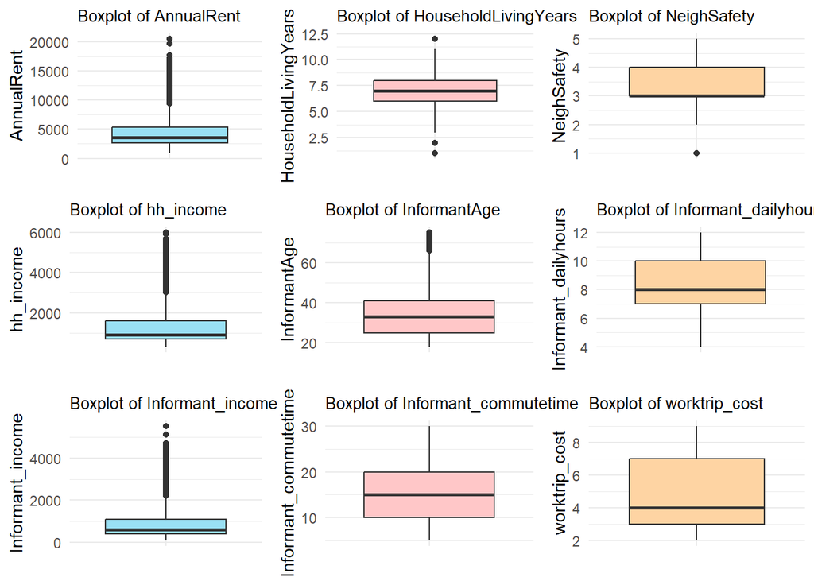

```r
library(gridExtra)  # for arranging plots

# We specify our preferred colors
colors <- c("#99E0F4", "#FFC7C8", "#FED4A3")

# Create and store boxplots in a list
plots <- list()
for (i in seq_along(numeric_vars)) {
    plot <- ggplot(hh_survey, aes_string(x = "factor(1)", y = numeric_vars[i])) +
        geom_boxplot(fill = colors[(i - 1) %% length(colors) + 1]) + # Rotate through colors
        labs(title = paste("Boxplot of", numeric_vars[i]), y = numeric_vars[i], x = "") +
        theme_minimal() +
        theme(axis.text.x = element_blank(), axis.ticks.x = element_blank(), plot.title = element_text(size = 10))
    plots[[i]] <- plot
}

# Arrange plots in a 3x3 grid
grid.arrange(grobs = plots, ncol = 3, nrow = 3)
```

### Histograms and Density Plots

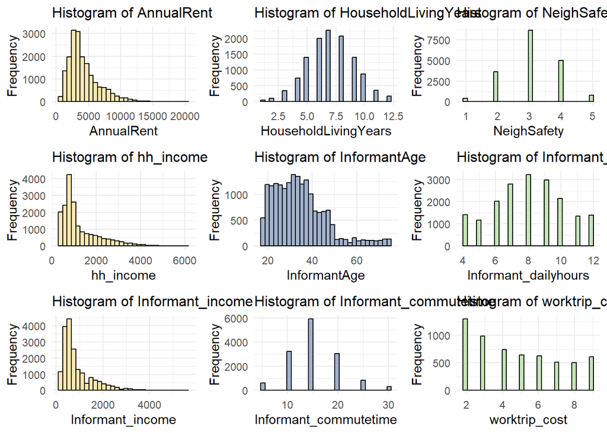

```r
# Specified colors
colors <- c("#FAE7B0", "#A0B2CD", "#C3E6B7")

# Create and display histograms for each variable using a loop
plots <- list()
for (i in seq_along(numeric_vars)) {
    # Select the color based on cycling through the list
    color_index <- (i - 1) %% length(colors) + 1
    plot <- ggplot(hh_survey, aes_string(x = numeric_vars[i])) +
        geom_histogram(fill = colors[color_index], color = "black", bins = 30) + # Black outline
        labs(title = paste("Histogram of", numeric_vars[i]), x = numeric_vars[i], y = "Frequency") +
        theme_minimal() +
        theme(plot.title = element_text(size = 12))
    plots[[i]] <- plot
}

# Display all plots using gridExtra::grid.arrange() for a 3x3 grid
library(gridExtra)
grid.arrange(grobs = plots, ncol = 3, nrow = 3)
```

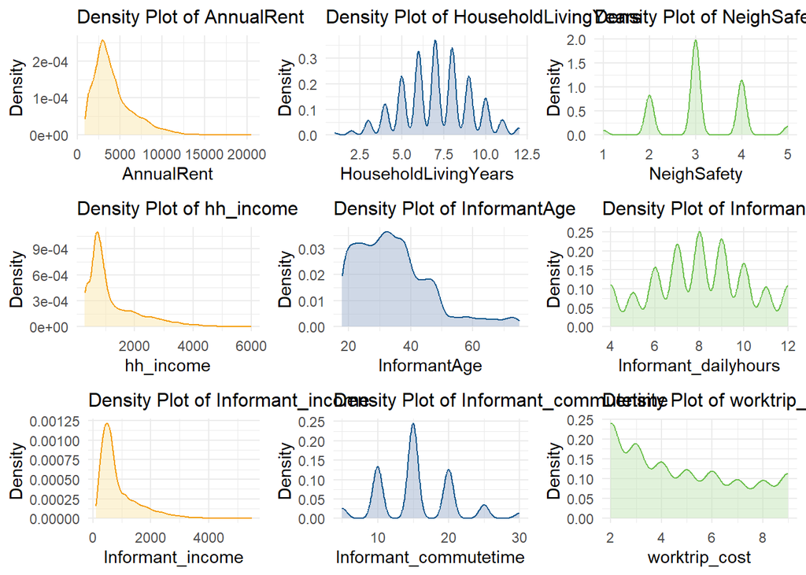

```r
# Specified colors for fills and lines
fill_colors <- c("#FAE7B0", "#A0B2CD", "#C3E6B7")
line_colors <- c("#F49C08", "#0A548B", "#6ABF4B")

# Create and display density plots for each variable using a loop
plots <- list()
for (i in seq_along(numeric_vars)) {
    # Select the color based on cycling through the list
    fill_index <- (i - 1) %% length(fill_colors) + 1
    line_index <- (i - 1) %% length(line_colors) + 1
    plot <- ggplot(hh_survey, aes_string(x = numeric_vars[i])) +
        geom_density(fill = fill_colors[fill_index], color = line_colors[line_index], alpha = 0.5) +  # Match line color
        labs(title = paste("Density Plot of", numeric_vars[i]), x = numeric_vars[i], y = "Density") +
        theme_minimal() +
        theme(plot.title = element_text(size = 12))
    plots[[i]] <- plot
}

# Display all plots using gridExtra::grid.arrange() for a 3x3 grid
library(gridExtra)
grid.arrange(grobs = plots, ncol = 3, nrow = 3)
```

# Working with Categorical Data

## Descriptive Statistics

When it comes to categorical data, the descriptive statistics focus on summarizing and understanding the distribution of categorical variables within our dataset. This includes techniques such as:

- **Frequency Tables.** These tables count the occurrences of each category within a variable, providing a straightforward view of the distribution across different groups. For example, counting how many respondents fall into each district or nationality category helps identify the most and least common categories.
- **Relative Frequency Tables.** These enhance frequency tables by converting counts into percentages, giving a clearer picture of the proportion each category represents in the dataset. This normalization allows for easier comparison between categories, especially when sample sizes vary.
- **Counting Observations.** Special counts, such as counting the occurrences of default or missing responses are critical for assessing the quality of the data and understanding how respondents interact with survey questions. This can highlight potential biases or issues in data collection.

### Frequency Tables

```r
# Frequency table for District
district_table <- table(hh_survey$District)
print(district_table)
```

```
##
## Flower Capital        Hakumai           Kibi           Kuri          Ringo
##           3646           2765           3324           3267           2490
##           Udon
##           3008
```

```r
# Frequency table for Informant_nationality
nationality_table <- table(hh_survey$Informant_nationality)
print(nationality_table)
```

```
##
##    Birkan  Fish-Man   Longarm   Longleg  Lunarian   Merfolk  Shandian  Skypiean
##      1485      2255      1454      1440      1371      2200      2572      1858
## Three-Eye
##      3865
```

### Relative Frequency Tables

```r
# Relative frequency table for Informant_edulevel
edu_level_freq <- hh_survey %>%
    group_by(Informant_edulevel) %>%
    summarise(Count = n()) %>%
    mutate(Relative_Frequency = Count / sum(Count) * 100) %>%
    arrange(desc(Relative_Frequency))

# Print the table
print(edu_level_freq)
```

```
## # A tibble: 11 × 3
##    Informant_edulevel                               Count Relative_Frequency
##    <chr>                                            <int>              <dbl>
##  1 Intermediate school completed (7th to 9th grade)  4774             25.8
##  2 Secondary school completed (10th to 12th grade)   4366             23.6
##  3 College/University completed                      3515             19
##  4 Primary school completed (first to 6th grade)     1960             10.6
##  5 Diploma (technical/vocational training)           1609              8.70
##  6 Less than primary school                          1258              6.8
##  7 No formal schooling (can read and write)           592              3.2
##  8 Masters/high diploma completed                     240              1.30
##  9 No formal schooling (cannot read and write)         93              0.503
## 10 Doctorate completed                                 56              0.303
## 11 <NA>                                                37              0.2
```

```r
# Relative frequency table for Informant_marital
marital_status_freq <- hh_survey %>%
    group_by(Informant_marital) %>%
    summarise(Count = n()) %>%
    mutate(Relative_Frequency = Count / sum(Count) * 100) %>%
    arrange(desc(Relative_Frequency))

# Print the table
print(marital_status_freq)
```

```
## # A tibble: 6 × 3
##   Informant_marital                                     Count Relative_Frequency
##   <chr>                                                 <int>              <dbl>
## 1 Currently married with nuclear family-spouse and kid…  7604              41.1
## 2 Currently married with nuclear family-spouse and kid…  3708              20.0
## 3 Divorced /separated                                    2471              13.4
## 4 Prefer not to answer                                   1749               9.45
## 5 Never married                                          1512               8.17
## 6 Widowed                                                1456               7.87
```

### Counting Observations

```r
# Security-related variables
security_vars <- c("Security_homerobbery", "Security_carrobbery",
                   "Security_personalrobbery", "Security_womenharassment",
                   "Security_childrenharassment", "Security_physicalattack",
                   "Security_verbalattack", "Security_drugsalcohol")

# Issues-related variables
issues_vars <- c("Issues_welcoming", "Issues_streets", "Issues_noise",
                 "Issues_buildings", "Issues_pedestrians", "Issues_parks",
                 "Issues_crime", "Issues_trafficparking", "Issues_cleanliness",
                 "Issues_shopping", "Issues_school", "Issues_pollution")
```

```r
# Function to count "Select" for a list of variables
count_select <- function(data, var_list) {
    data %>%
        select(all_of(var_list)) %>%
        summarise(across(everything(), ~ sum(. == "Select", na.rm = TRUE))) %>%
        pivot_longer(cols = everything(), names_to = "Variable", values_to = "SelectCount")
}

# Count "Select" for security-related variables
security_select_counts <- count_select(hh_survey, security_vars)
print(security_select_counts)
```

```
## # A tibble: 8 × 2
##   Variable                    SelectCount
##   <chr>                             <int>
## 1 Security_homerobbery                462
## 2 Security_carrobbery                 588
## 3 Security_personalrobbery           1143
## 4 Security_womenharassment            860
## 5 Security_childrenharassment         532
## 6 Security_physicalattack             979
## 7 Security_verbalattack              1344
## 8 Security_drugsalcohol              1266
```

```r
# Count "Select" for issues-related variables
issues_select_counts <- count_select(hh_survey, issues_vars)
print(issues_select_counts)
```

```
## # A tibble: 12 × 2
##    Variable              SelectCount
##    <chr>                       <int>
##  1 Issues_welcoming              198
##  2 Issues_streets                578
##  3 Issues_noise                  777
##  4 Issues_buildings              936
##  5 Issues_pedestrians            355
##  6 Issues_parks                  318
##  7 Issues_crime                 1334
##  8 Issues_trafficparking         768
##  9 Issues_cleanliness           1255
## 10 Issues_shopping               836
## 11 Issues_school                 612
## 12 Issues_pollution             1201
```

## Visualizations

In the analysis of categorical data, we can also employ several types of visualizations to enhance understanding and facilitate the communication of data insights:

- **Bar Charts.** These are fundamental for visualizing the distribution of categorical data. Vertical bar charts are used to display the frequency or count of categories, making it easy to compare the size of different groups. For instance, we might use a bar chart to show the distribution of economic activity among respondents. Adding gradient colors and annotations of counts on the bars enhances readability and aesthetic appeal, highlighting differences more vividly.
- **Horizontal Bar Charts.** Similar to vertical bar charts, horizontal bars are particularly useful for categories with longer names or when there are many categories to display. By flipping the orientation, we can make better use of space and improve legibility. This is effective for displaying data like the frequency of “Select” responses in neighborhood-related variables.
- **Stacked Bar Charts.** These charts extend the bar chart by dividing each bar into multiple segments that represent different sub-categories within the main category, allowing for a comparison of proportions across different groups within a single bar. For example, in visualizing utility data, a stacked bar chart can show the proportion of responses that are “Select” versus “NA” for different utilities, providing a clear visual representation of the composition of each category.
- **Pie Charts.** Pie charts provide a clear illustration of how each category contributes to the total, using segments of a circle whose sizes are proportional to the data values. Although their use is generally discouraged, they can be useful when the data involves few proportions of a whole. They are particularly effective for showing the distribution of gender or binary responses, as they highlight the relative sizes of the groups at a glance.

### Bar Charts

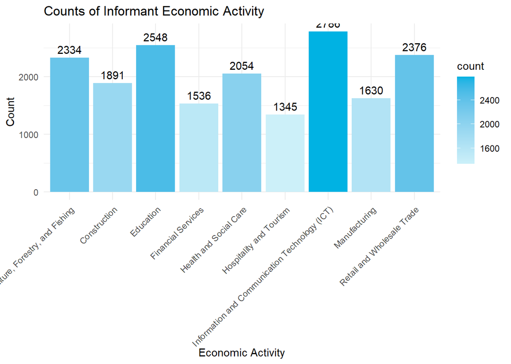

```r
# Create a vertical bar chart for Informant_econactivity with gradient colors and counts on top
ggplot(hh_survey, aes(x = Informant_econactivity)) +
    geom_bar(aes(fill = ..count..), stat = "count") +  # Fill based on count
    geom_text(stat = "count", aes(label = ..count.., y = ..count..), vjust = -0.5, color = "black") +  # Add counts
    scale_fill_gradient(low = "#CCF0F9", high = "#00B2E3") +
    labs(title = "Counts of Informant Economic Activity",
         x = "Economic Activity",
         y = "Count") +
    theme_minimal() +
    theme(axis.text.x = element_text(angle = 45, hjust = 1))  # Improve label readability
```

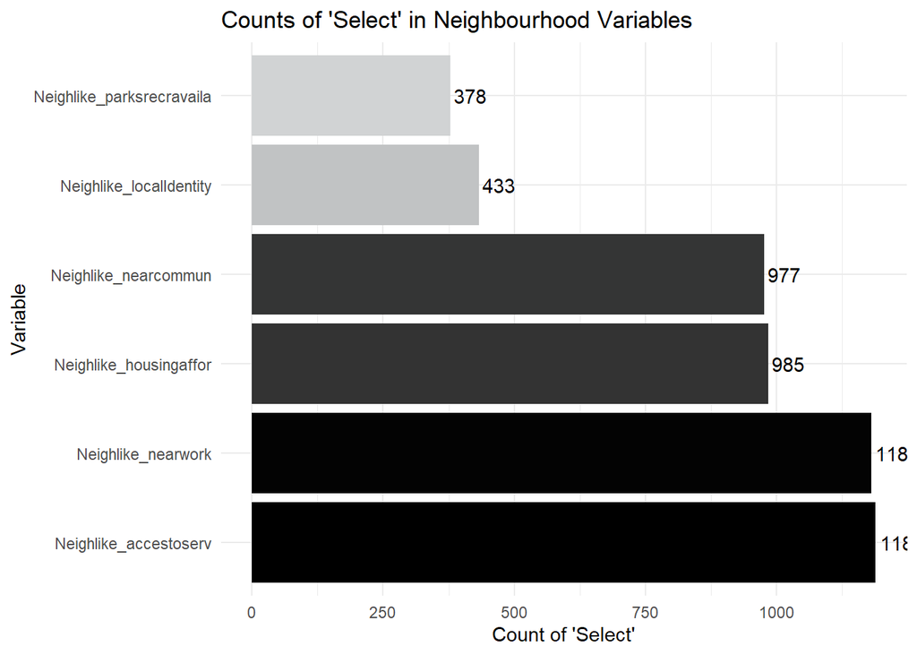

```r
# Define the neighbourhood variables
neigh_vars <- c("Neighlike_accestoserv", "Neighlike_housingaffor", "Neighlike_nearcommun",
                "Neighlike_nearwork", "Neighlike_localIdentity", "Neighlike_parksrecravaila")

# Create a data frame for "Select" counts
neigh_select_counts <- hh_survey %>%
    select(all_of(neigh_vars)) %>%
    summarise(across(everything(), ~ sum(. == "Select", na.rm = TRUE))) %>%
    pivot_longer(cols = everything(), names_to = "Variable", values_to = "SelectCount")

# Create a horizontal bar chart with gradient colors and counts
ggplot(neigh_select_counts, aes(x = reorder(Variable, -SelectCount), y = SelectCount, fill = SelectCount)) +
  geom_bar(stat = "identity") +  # Specify bar properties
  geom_text(aes(label = SelectCount, x = Variable, y = SelectCount), position = position_dodge(width = 0.9), hjust = -0.1, color = "black") +
  coord_flip() +  # Flip coordinates for horizontal bars
  scale_fill_gradient(low = "#D1D3D4", high = "#000000") +
  labs(title = "Counts of 'Select' in Neighbourhood Variables",
       x = "Variable",
       y = "Count of 'Select'") +
  theme_minimal() +
  theme(legend.position = "none")  # Remove legend if not needed
```

### Stacked Bar Charts

```r
# Prepare the data correctly
utility_data <- hh_survey %>%
    select(Utility_electricity_available, Utility_water_available, Utility_sanitation_available) %>%
    pivot_longer(cols = everything(), names_to = "Utility", values_to = "Status") %>%
    mutate(Status = case_when(
        Status == "Select" ~ "Select",
        is.na(Status) ~ "NA",
        TRUE ~ "Other"
    )) %>%
    group_by(Utility, Status) %>%
    summarise(Count = n(), .groups = 'drop') %>%
    group_by(Utility) %>%  # Re-group by Utility to sum "Select" and "NA" correctly
    mutate(Total = sum(Count[Status %in% c("Select", "NA")]),
           Percentage = (Count / Total) * 100)

# View the data to confirm preparation
print(utility_data)
```

```
## # A tibble: 6 × 5
## # Groups:   Utility [3]
##   Utility                       Status Count Total Percentage
##   <chr>                         <chr>  <int> <int>      <dbl>
## 1 Utility_electricity_available NA      1665 18500          9
## 2 Utility_electricity_available Select 16835 18500         91
## 3 Utility_sanitation_available  NA      1295 18500          7
## 4 Utility_sanitation_available  Select 17205 18500         93
## 5 Utility_water_available       NA      1480 18500          8
## 6 Utility_water_available       Select 17020 18500         92
```

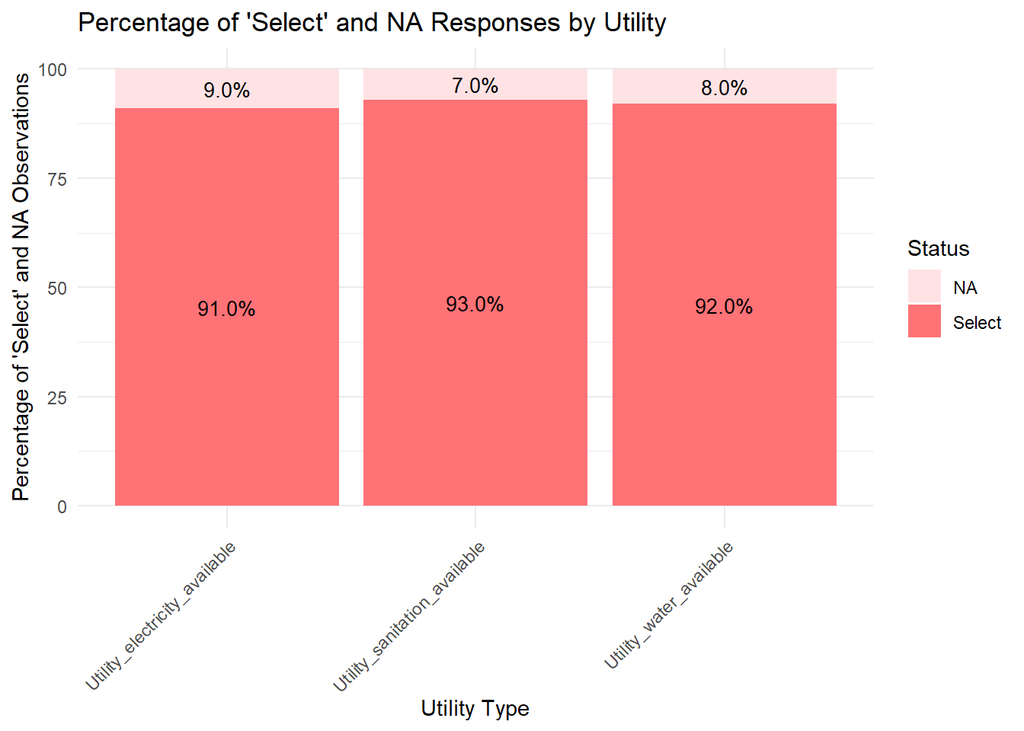

```r
# Create a vertical stacked bar chart
ggplot(utility_data %>% filter(Status %in% c("Select", "NA")),  # Include only Select and NA for plotting
       aes(x = Utility, y = Percentage, fill = Status)) +
    geom_bar(stat = "identity") +
    scale_fill_manual(values = c("Select" = "#FF7276", "NA" = "#FFE3E4")) +
    geom_text(aes(label = sprintf("%.1f%%", Percentage)), position = position_stack(vjust = 0.5), size = 3.5) +
    labs(title = "Percentage of 'Select' and NA Responses by Utility",
         x = "Utility Type",
         y = "Percentage of 'Select' and NA Observations") +
    theme_minimal() +
    theme(axis.text.x = element_text(angle = 45, hjust = 1))
```

### Pie Charts

```r
# Prepare the data
gender_data <- hh_survey %>%
    count(InformantGender) %>%
    mutate(Percentage = n / sum(n) * 100)

# View the data
print(gender_data)
```

```
## # A tibble: 2 × 3
##   InformantGender     n Percentage
##   <chr>           <int>      <dbl>
## 1 Female           1910       10.3
## 2 Male            16590       89.7
```

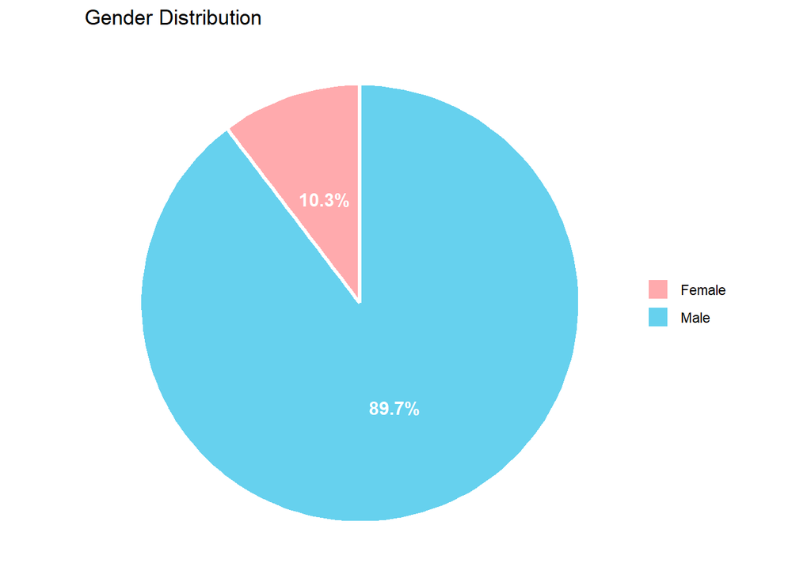

```r
# Create a pie chart with updated aesthetics for ggplot2 3.4.0+
ggplot(gender_data, aes(x = "", y = Percentage, fill = InformantGender)) +
    geom_bar(stat = "identity", width = 1, color = "white", linewidth = 1.2) +  # Use linewidth for a thicker white line
    coord_polar(theta = "y") +  # Polar coordinates to create pie chart
    scale_fill_manual(values = c(Male = "#66D1EE", Female = "#FFAAAD")) +
    geom_text(aes(label = sprintf("%.1f%%", Percentage)), position = position_stack(vjust = 0.5),
              color = "white", fontface = "bold", size = 4) +  # Make text bold and slightly larger
    labs(title = "Gender Distribution", x = NULL, y = NULL) +  # Clean up labels
    theme_void() +  # Remove background and grid
    theme(legend.title = element_blank())  # Remove legend title
```

```r
# Prepare the data for Neighlike_Binary
neighlike_data <- hh_survey %>%
    mutate(Neighlike_Binary = ifelse(Neighlike_Binary == 1, "Yes", "No")) %>%
    count(Neighlike_Binary) %>%
    mutate(Percentage = n / sum(n) * 100)

# View the data
print(neighlike_data)
```

```
## # A tibble: 3 × 3
##   Neighlike_Binary     n Percentage
##   <chr>            <int>      <dbl>
## 1 No                6981       37.7
## 2 Yes               9484       51.3
## 3 <NA>              2035       11
```

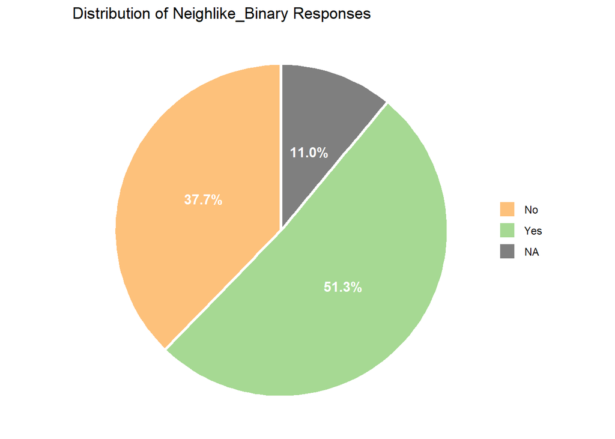

```r
# Create a pie chart for Neighlike_Binary with separated slices
ggplot(neighlike_data, aes(x = "", y = Percentage, fill = Neighlike_Binary)) +
    geom_bar(stat = "identity", width = 1, color = "white", size = 1.2) +  # Use geom_bar and specify the white line and its thickness
    coord_polar(theta = "y") +  # Polar coordinates to create pie chart
    scale_fill_manual(values = c("Yes" = "#A6D993", "No" = "#FDC17B")) +
    geom_text(aes(label = sprintf("%.1f%%", Percentage)), position = position_stack(vjust = 0.5), color = "white", fontface = "bold", size = 4) +
    labs(title = "Distribution of Neighlike_Binary Responses", x = NULL, y = NULL) +
    theme_void() +  # Remove background and grid
    theme(legend.title = element_blank())  # Remove legend title
```

# Correlation Analysis

Correlation analysis is a fundamental step in exploratory data analysis that helps identify and quantify relationships between variables. By measuring the degree to which two variables move together, we can uncover patterns that inform economic and social policies. In this section, we will explore different types of correlation techniques suitable for various types of data, including continuous, ordinal, and binary variables.

Correlation analysis allows us to:

- Detect potential linear or monotonic relationships between variables.
- Identify multicollinearity, which can affect regression models.
- Provide insights for further hypothesis testing or predictive modeling.

## Pearson Correlation

Pearson correlation measures the linear relationship between two continuous variables. It is suitable when both variables follow a normal distribution and assumes homoscedasticity (constant variance). The coefficient ranges from -1 (perfect negative correlation) to 1 (perfect positive correlation), with 0 indicating no correlation. We will visualize these correlations using a correlation matrix and heatmaps.

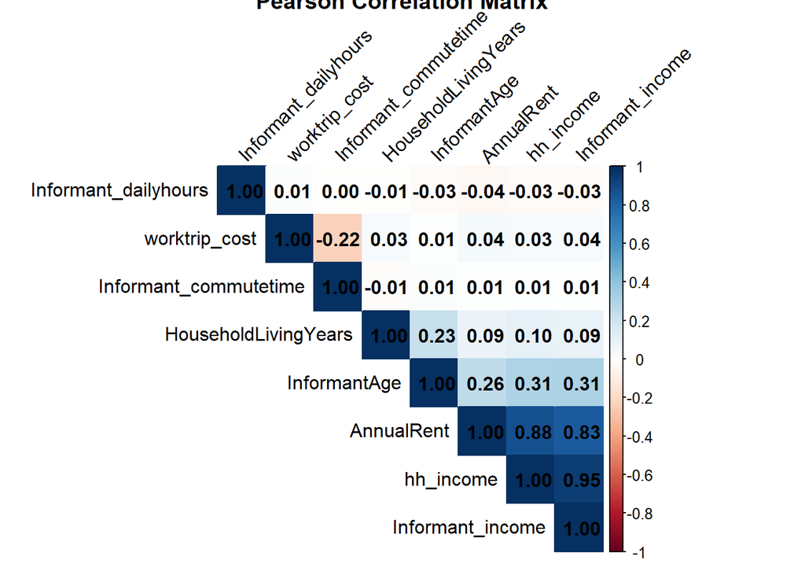

```r
# Load necessary libraries
library(corrplot)

# Define the list of conitnuous variables
cont_vars <- c("AnnualRent", "HouseholdLivingYears",
                  "hh_income", "InformantAge", "Informant_dailyhours",
                  "Informant_income", "Informant_commutetime", "worktrip_cost")

# Subset the data frame to include only the specified numeric variables
data_subset <- hh_survey[cont_vars]

# Calculate the Pearson correlation matrix
cor_matrix <- cor(data_subset, use = "complete.obs", method = "pearson")

# Visualize the correlation matrix using corrplot
corrplot(cor_matrix, method = "color",
         color = colorRampPalette(c("#00B2E3", "#FF7276"))(200),  # Gradient from blue to red
         type = "upper",  # Show only the upper half of the matrix
         order = "hclust",  # Order variables using hierarchical clustering
         tl.col = "black",  # Text label color
         tl.srt = 45,       # Text label rotation
         title = "Pearson Correlation Matrix",
         addCoef.col = "black")  # Add correlation coefficients to the plot
```

## Spearman Correlation

Spearman correlation is a non-parametric alternative to Pearson correlation. It measures the rank-order relationship between two variables, making it suitable for ordinal data or when the relationship is non-linear but still monotonic (i.e., consistently increasing or decreasing). This method is useful when working with ranked variables like education levels or socioeconomic status indicators.

```r
# Include NeighSafety in the data subset
data_subset <- hh_survey %>%
    select(NeighSafety, all_of(cont_vars))

# Calculate the Spearman correlation of NeighSafety with other variables
spearman_correlation <- cor(data_subset, method = "spearman", use = "complete.obs")

# Extracting the Spearman correlation coefficients for NeighSafety with other variables
neigh_safety_correlation <- spearman_correlation['NeighSafety', ]

# Print the correlation of NeighSafety with other variables
print(neigh_safety_correlation)
```

```
##           NeighSafety            AnnualRent  HouseholdLivingYears
##           1.000000000          -0.063099704          -0.019073501
##             hh_income          InformantAge  Informant_dailyhours
##          -0.065013081          -0.073145796           0.017874159
##      Informant_income Informant_commutetime         worktrip_cost
##          -0.055543503          -0.001204431          -0.016058668
```

## Point-Biserial Correlation

Point-biserial correlation measures the relationship between a continuous variable and a binary variable (e.g., income and homeownership status). It is a special case of Pearson correlation but adapted for binary data. This technique is particularly useful in socioeconomic studies where we want to assess how a binary condition (e.g., employed vs. unemployed) influences a continuous measure (e.g., household income).

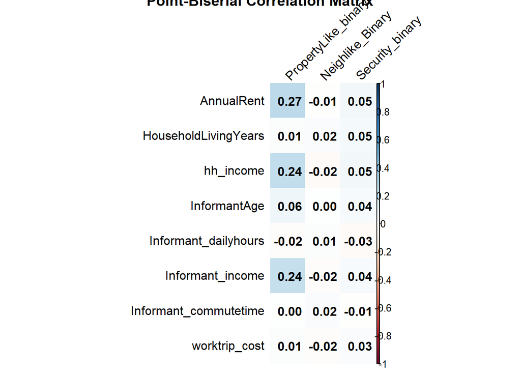

```r
# Calculate the point-biserial correlation matrix including binary and continuous variables
cor_matrix <- cor(hh_survey[c(cont_vars, "PropertyLike_binary", "Neighlike_Binary", "Security_binary")],
                  method = "pearson", use = "complete.obs")

# Subset the correlation matrix to show only correlations between continuous and binary variables
# Assuming 'cont_vars' are your continuous variables and the rest are binary
binary_vars <- c("PropertyLike_binary", "Neighlike_Binary", "Security_binary")
cor_subset = cor_matrix[cont_vars, binary_vars]

# We use corrplot to visualize the subselected correlation matrix
corrplot(cor_subset, method = "color",
         color = colorRampPalette(c("#00B2E3", "#FF7276"))(200),
         title = "Point-Biserial Correlation Matrix",
         tl.col = "black",
         tl.srt = 45,
         addCoef.col = "black") # Adds the correlation coefficient values
```

## Simpson’s Paradox

The Simpson’s Paradox is a statistical phenomenon where a trend that appears in several different groups of data disappears or reverses when these groups are combined. This paradox occurs when underlying variables, often unaccounted for in initial analyses, confound the overall results. It highlights the importance of considering context and stratification when interpreting aggregated data.

We can illustrate this phenomenon by looking at the average values of `Informant_income` grouped by `Informant_edulevel` and then further segmenting by `Informant_nationality`.

When looking at the aggregated data we can clearly see that those with PhD studies have higher salaries than those with Master’s degrees.

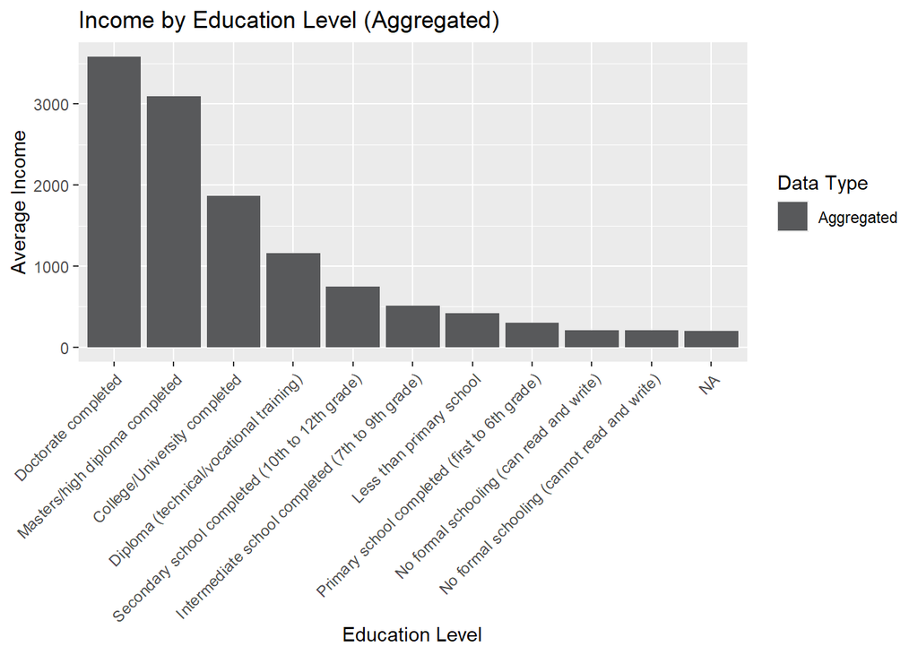

```r
# Grouping income by educational level and sorting in descending order of income
income_education_aggregated <- hh_survey %>%
    group_by(Informant_edulevel) %>%
    summarise(Average_Income = mean(Informant_income, na.rm = TRUE), .groups = 'drop') %>%
    arrange(desc(Average_Income)) # Arrange by descending income

# Plotting aggregated data with reordered education levels
ggplot(income_education_aggregated, aes(x = reorder(Informant_edulevel, -Average_Income), y = Average_Income, fill = "Aggregated")) +
    geom_bar(stat = "identity") +
    labs(title = "Income by Education Level (Aggregated)", x = "Education Level", y = "Average Income") +
    theme(axis.text.x = element_text(angle = 45, hjust = 1)) +
    scale_fill_manual(values = c("Aggregated" = "#58595B")) +
    guides(fill = guide_legend(title = "Data Type"))
```

But after grouping individual income level by both educational level and nationality, a different trend appears for “Birkan” and “Longarm” individuals: those with a Master’s degree tend to have higher incomes than those with a PhD.

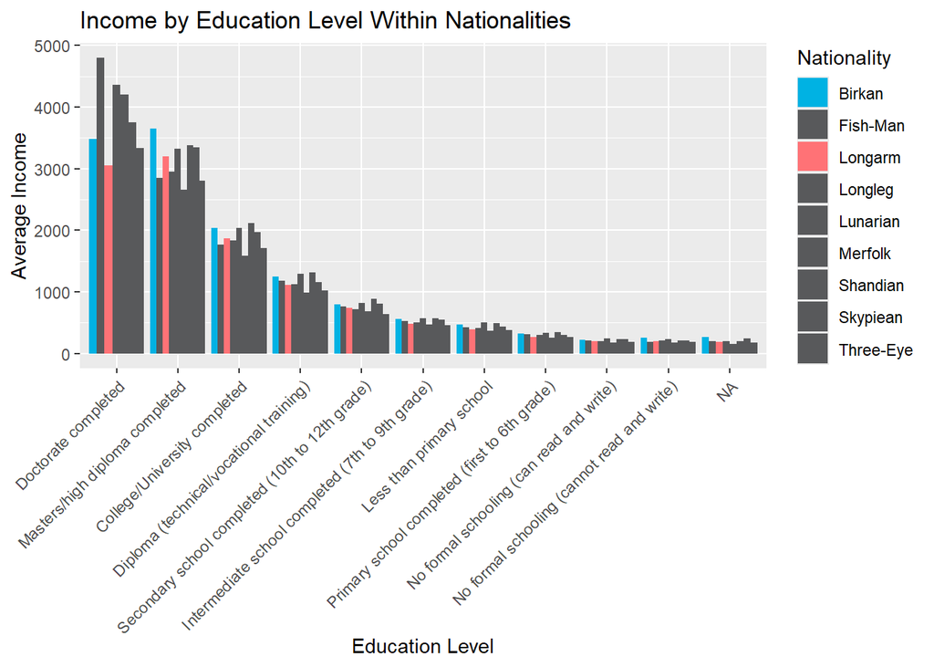

```r
# Calculating overall average income per education level across all nationalities
education_avg_income <- hh_survey %>%
    group_by(Informant_edulevel) %>%
    summarise(Overall_Average_Income = mean(Informant_income, na.rm = TRUE), .groups = 'drop')

# Merging this overall ranking into the dataset for ordering purposes
income_education_by_district <- hh_survey %>%
    group_by(Informant_nationality, Informant_edulevel) %>%
    summarise(Average_Income = mean(Informant_income, na.rm = TRUE), .groups = 'drop') %>%
    left_join(education_avg_income, by = "Informant_edulevel") %>%
    arrange(desc(Overall_Average_Income))  # Arrange education levels by overall income

# Defining custom colors for nationalities
nationalities <- unique(income_education_by_district$Informant_nationality)
colors <- setNames(rep("#58595B", length(nationalities)), nationalities)
colors["Birkan"] <- "#00B2E3"
colors["Longarm"] <- "#FF7276"

# Plotting with education levels ordered by overall average income
ggplot(income_education_by_district, aes(x = reorder(Informant_edulevel, -Overall_Average_Income),
                                         y = Average_Income, fill = Informant_nationality)) +
    geom_bar(stat = "identity", position = position_dodge()) +
    labs(title = "Income by Education Level Within Nationalities", x = "Education Level", y = "Average Income") +
    theme(axis.text.x = element_text(angle = 45, hjust = 1)) +
    scale_fill_manual(values = colors) +
    guides(fill = guide_legend(title = "Nationality"))
```

Challenges like Simpson’s Paradox underscore the necessity for segmenting socio-economic data that will be explored in the next section on “Data Stratification and Comparative Analysis.” Segmentation ensures a comprehensive analysis by dividing data into relevant subgroups such as nationality, income levels, or geographic locations. This approach not only clarifies interactions between variables within these subgroups but also enhances policy relevance by tailoring insights to diverse demographic needs. Additionally, using advanced analytical techniques can illuminate distinct trends and support informed decision-making, thus avoiding oversights that could arise from solely aggregated data interpretations.

# From Exploratory Analysis to Inferential Statistics

## Hypothesis Testing: Are Master’s Holders Actually Better Paid Than PhD Holders?

### Introduction

In the previous section, we identified a case of **Simpson’s Paradox**: while at the aggregate level, PhD holders appear to have higher incomes than those with a master’s degree, when segmented by nationality, the pattern reverses for the “Birkan” and “Longarm” groups. However, we have **very few observations for PhD holders**, raising the question: is this difference in income statistically significant, or is it just random variation?

To answer this, we conduct **hypothesis testing**, a fundamental tool in inferential statistics that allows us to determine whether the observed differences in our sample reflect true differences in the population.

### Framing the Hypothesis

We define our hypotheses as follows:

- **Null Hypothesis (H_0):** There is no significant difference in average income between master’s and PhD holders.
- **Alternative Hypothesis (H_a):** Master’s degree holders earn significantly more than PhD holders (one-tailed test).

If our hypothesis test results in a **p-value < 0.05**, we reject the null hypothesis and conclude that the income difference is statistically significant.

### Choice of Statistical Test

Our test choice depends on **sample size**:

- If both groups have **at least 30 observations**, we use the **independent samples t-test**.
- If the PhD group has **fewer than 30 observations**, we use the **Mann-Whitney U test**, a non-parametric alternative that does not assume normality.

### Conducting the Test in R

#### Checking Sample Sizes and Income Distributions

```r
# Summarizing sample sizes and income statistics for each subgroup
sampling_summary <- hh_survey %>%
  filter(Informant_nationality %in% c("Birkan", "Longarm") & Informant_edulevel %in% c("Masters/high diploma completed", "Doctorate completed")) %>%
  group_by(Informant_nationality, Informant_edulevel) %>%
  summarise(
    Sample_Size = n(),
    Mean_Income = mean(Informant_income, na.rm = TRUE),
    SD_Income = sd(Informant_income, na.rm = TRUE),
    Min_Income = min(Informant_income, na.rm = TRUE),
    Max_Income = max(Informant_income, na.rm = TRUE),
    .groups = 'drop'
  )

# Print the summary table
print(sampling_summary)
```

```
## # A tibble: 4 × 7
##   Informant_nationality Informant_edulevel     Sample_Size Mean_Income SD_Income
##   <chr>                 <chr>                        <int>       <dbl>     <dbl>
## 1 Birkan                Doctorate completed              9       3478.      346.
## 2 Birkan                Masters/high diploma …          23       3648.      543.
## 3 Longarm               Doctorate completed              9       3056.      629.
## 4 Longarm               Masters/high diploma …          28       3204.      371.
## # ℹ 2 more variables: Min_Income <dbl>, Max_Income <dbl>
```

```r
# Optional: Display the table in a nicely formatted way using knitr
library(knitr)
kable(sampling_summary, caption = "Summary of Sample Sizes and Income Statistics by Group")
```

Summary of Sample Sizes and Income Statistics by Group

| Informant_nationality | Informant_edulevel | Sample_Size | Mean_Income | SD_Income | Min_Income | Max_Income |
| --- | --- | --- | --- | --- | --- | --- |
| Birkan | Doctorate completed | 9 | 3477.778 | 345.6074 | 3100 | 4200 |
| Birkan | Masters/high diploma completed | 23 | 3647.826 | 543.4482 | 2700 | 4700 |
| Longarm | Doctorate completed | 9 | 3055.556 | 628.7112 | 2400 | 4100 |
| Longarm | Masters/high diploma completed | 28 | 3203.571 | 370.6672 | 2700 | 4000 |

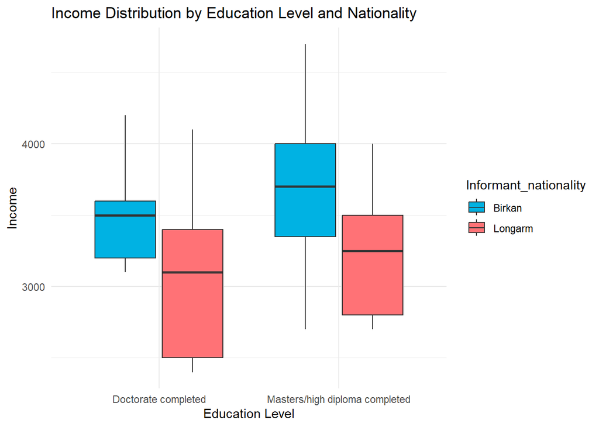

```r
# Optional: Create a boxplot to visualize income distributions
# Define custom colors for nationalities
colors <- c("Birkan" = "#00B2E3", "Longarm" = "#FF7276")

# Create the boxplot
ggplot(hh_survey %>% filter(Informant_nationality %in% c("Birkan", "Longarm") & Informant_edulevel %in% c("Masters/high diploma completed", "Doctorate completed")),
       aes(x = Informant_edulevel, y = Informant_income, fill = Informant_nationality)) +
  geom_boxplot() +
  scale_fill_manual(values = colors) +  # Ensure consistent colors
  labs(title = "Income Distribution by Education Level and Nationality", x = "Education Level", y = "Income") +
  theme_minimal()
```

#### Conducting a T-test or Mann-Whitney U test for Each Group

```r
# Filtering the data for Birkan individuals only
birkan_masters_income <- hh_survey %>% filter(Informant_nationality == "Birkan" & Informant_edulevel == "Masters/high diploma completed") %>% pull(Informant_income)
birkan_phd_income <- hh_survey %>% filter(Informant_nationality == "Birkan" & Informant_edulevel == "Doctorate completed") %>% pull(Informant_income)

# Filtering the data for Longarm individuals only
longarm_masters_income <- hh_survey %>% filter(Informant_nationality == "Longarm" & Informant_edulevel == "Masters/high diploma completed") %>% pull(Informant_income)
longarm_phd_income <- hh_survey %>% filter(Informant_nationality == "Longarm" & Informant_edulevel == "Doctorate completed") %>% pull(Informant_income)

# Function to perform hypothesis testing for a subgroup
run_hypothesis_test <- function(masters_income, phd_income, group_name) {
    cat("\n\n=== Hypothesis Test for", group_name, "===\n")

    if (length(masters_income) >= 30 & length(phd_income) >= 30) {
        test_result <- t.test(masters_income, phd_income, alternative = "greater", var.equal = FALSE)
    } else {
        test_result <- wilcox.test(masters_income, phd_income, alternative = "greater")
    }

    print(test_result)
}

# Run the tests for both subgroups
run_hypothesis_test(birkan_masters_income, birkan_phd_income, "Birkan")
```

```
##
##
## === Hypothesis Test for Birkan ===
```

```
##
##  Wilcoxon rank sum test with continuity correction
##
## data:  masters_income and phd_income
## W = 131, p-value = 0.1282
## alternative hypothesis: true location shift is greater than 0
```

```r
run_hypothesis_test(longarm_masters_income, longarm_phd_income, "Longarm")
```

```
##
##
## === Hypothesis Test for Longarm ===
```

```
##
##  Wilcoxon rank sum test with continuity correction
##
## data:  masters_income and phd_income
## W = 154, p-value = 0.1641
## alternative hypothesis: true location shift is greater than 0
```

#### Interpreting the Results

- **p-value (Birkan) = 0.1282**
- **p-value (Longarm) = 0.1641**

Since both **p-values are greater than 0.05**, we **fail to reject the null hypothesis** (H_0). This means that the observed income difference between master’s and PhD holders in the Birkan and Longarm groups is not statistically significant. The differences seen in the EDA may be due to random variation rather than a true underlying trend.